# p8105_hw1_jt3649

Juan Tang

2025-09-20

## Problem 1

```r
library(moderndive)
library(tidyverse)
data("early_january_weather")
```

### Dataset Description

The `early_january_weather` dataset has 358 rows (observations) and 15 columns (variables).

The variables in this dataset are: origin, year, month, day, hour, temp, dewp, humid, wind_dir, wind_speed, wind_gust, precip, pressure, visib, time_hour.

The mean temperature across all observations is 39.5821229 ºF.

### Scatterplot of temp vs time_hour

Code for Scatterplot

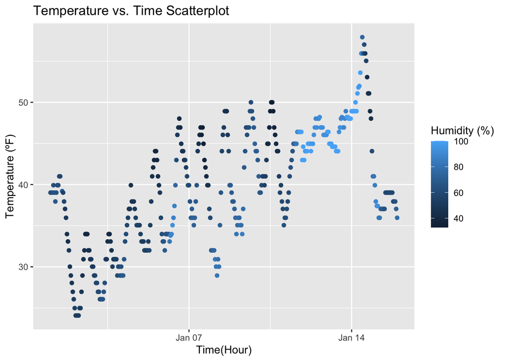

```r
ggplot(early_january_weather,
       aes(x = time_hour,
           y = temp,
           color = humid
       )) + geom_point() + labs(title = "Temperature vs. Time Scatterplot",
             x = "Time(Hour)",
             y = "Temperature (ºF)",
             color = "Humidity (%)")
```

Saving the plot

```r
ggsave("temperature_vs_time_hour_Scatterplot.png", width = 8, height = 6)
```

### Description of Scatterplot

The scatterplot shows how temperature in New York changed during the first two weeks of January 2013, with x-axis representing time, y-axis representing temperature in ºF, and point color representing humidity. The pattern shows a regular daily fluctuation in temperature, presenting a consistent wave-like pattern.The temperature rises during daylight hours and falls at night. Across the two-week period, there appears to be a general upward trend in temperatures, with later days showing higher temperatures overall compared to the beginning of the period. Around January 14, there is a noticeable peak where the temperature exceeded 56°F.

## Problem 2

Creating a dataframe

```r
df=tibble(
  random_sample = rnorm(10),
  logical_vec = random_sample > 0,
  char_vec = letters[1:10],
  factor_vec = factor(rep(c("low", "medium", "high"),
                          length.out = 10),
                      levels = c("low", "medium", "high"))
)
```

This is the dataframe for problem 2:

```r
df
```

```
## # A tibble: 10 × 4
##    random_sample logical_vec char_vec factor_vec
##            <dbl> <lgl>       <chr>    <fct>
##  1        1.97   TRUE        a        low
##  2        0.739  TRUE        b        medium
##  3       -1.14   FALSE       c        high
##  4       -0.0789 FALSE       d        low
##  5        1.63   TRUE        e        medium
##  6        0.296  TRUE        f        high
##  7        0.0196 TRUE        g        low
##  8       -0.465  FALSE       h        medium
##  9        0.719  TRUE        i        high
## 10        1.68   TRUE        j        low
```

Take the mean of each variable in the dataframe df

```r
#valid output for numeric variable
mean_random_sample = mean(pull(df, "random_sample"))
cat("Mean of random sample variable =", mean_random_sample)
```

```
## Mean of random sample variable = 0.5373136
```

```r
#valid output for logical variable
mean_logical_vec = mean(pull(df, "logical_vec"))
cat("Mean of logical vector =", mean_logical_vec)
```

```
## Mean of logical vector = 0.7
```

```r
#invalid output for character variable
mean_char_vec = mean(pull(df, "char_vec"))
#invalid output for factor variable
mean_factor_vec = mean(pull(df, "factor_vec"))
```

### Explanation

The mean of random_sample is 0.5373136. This mean works because it’s numeric value. The mean of logical_vec is 0.7. This mean also works because logical values are coerced to 0 (False) or 1 (TRUE). When a mean is requested, the system automatically convert each TRUE to a 1 and each FALSE to a 0. It then adds up all the 1s and 0s, and devides the sum by the total number of values in the list. char_vec and factor_vec cannot take mean values because they are text and categorical labels.

### as.numeric Function

```r
as.numeric(pull(df, "random_sample"))
```

```
##  [1]  1.96879897  0.73901716 -1.14018223 -0.07886568  1.63486924  0.29633708
##  [7]  0.01955820 -0.46518680  0.71922510  1.67956524
```

```r
as.numeric(pull(df, "logical_vec"))
```

```
##  [1] 1 1 0 0 1 1 1 0 1 1
```

```r
as.numeric(pull(df, "factor_vec"))
```

```
##  [1] 1 2 3 1 2 3 1 2 3 1
```